# Mileage per Gallon Predictor

14 June 2019

## Application Summary

This application predicts mileage per gallon of your car based on some specifications such as horsepower, number of cylinders and gear transmission mode.  
The prediction model in based upon **mtcars** dataset in R

```
                   mpg cyl disp  hp drat    wt  qsec vs am gear carb
Mazda RX4         21.0   6  160 110 3.90 2.620 16.46  0  1    4    4
Mazda RX4 Wag     21.0   6  160 110 3.90 2.875 17.02  0  1    4    4
Datsun 710        22.8   4  108  93 3.85 2.320 18.61  1  1    4    1
Hornet 4 Drive    21.4   6  258 110 3.08 3.215 19.44  1  0    3    1
Hornet Sportabout 18.7   8  360 175 3.15 3.440 17.02  0  0    3    2
Valiant           18.1   6  225 105 2.76 3.460 20.22  1  0    3    1
```

Source Code: [Github](http://github.com/gomugomu0034/Shiny-App)

Application: [ShinyApp](https://sanketbambodkar.shinyapps.io/mpgpredictor/)

## How It Works

- The application is written in **Shiny** which is a web application framework for R
- The source code consists of two files: server.R and ui.R
- **server.R** includes the the server logic of a Shiny web application
- **ui.R** includes the the user-interface definition, which uses the sidebarLayout template
- The application is hosted on Rstudio's shiny server in the cloud (**Shinyapps.io**)

## Model Design

Models are based on **mtcars** dataset in R  
**Model 1** is a simplistic model with mileage per gallon as the outcome and horsepower as the predictor.  
**Model 2** is a multivariable model which uses horsepower, number of cylinders and geat transmission mode as the predictors.

```r
model1 <- lm(mpg ~ hp, data = mtcars)
model2 <- lm(mpg ~ hp + factor(cyl) + factor(am), data = mtcars)
hpInput <- input$hp
if(input$am == "Automatic") {amInput <- 1} else {amInput <- 0}
cylInput <- input$cyl
model1pred <- reactive({
          predict(model1, newdata = data.frame(hp = hpInput))})
model2pred <- reactive({
predict(model2, newdata = data.frame(hp = hpInput,
        cyl = cylInput, am = amInput))})
```

## Prediction Outpuut

This is a graph between mileage per gallon (y axis) vs horsepower (x axis).  
Red line denotes model 1 and blue line denotes model 2.

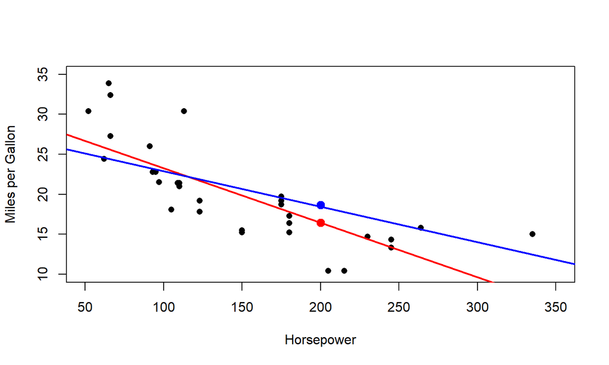

```
## integer(0)
```